# “Tuke” Versus the Big Leagues: Examining the Accuracy of NBA 2K20 Player Ratings in the Scope of the 2019 NBA Season

By Sharattram Seenivasan, Ethan Millstone, and Sahil Arora

## Introduction

Every year, 2K studios release a new and improved version of their popular basketball simulator, NBA 2K. With each iteration, gamers can expect an upgrade of graphics quality, an increase in online multiplayer game modes and capabilities, and of course, an all-new up-to-date ranking of every player in the NBA. A player’s ranking is determined through proprietary methods and it is supposed to accurately represent their skill and reflect their real-life basketball prowess. Professional ballers have been known to take offense when they feel their rating is too low, taking to Twitter to vent their anger in a passive-aggressive fashion. Although we don’t know exactly how 2K studios develop their player-rating algorithm, we can compare their in-game generated values to real-game statistics. The data we used for the NBA 2K player ratings comes from a publicly available database that mirrors all players’ in-game attributes in a table. Real-life game data comes from NBAStuffer, a one-of-a-kind resource for comprehensive basketball statistics, analytics, and data.

## Technology/Datasets used:

These links below include the Python and python libraries we used to conduct our analyses. If you’d like to be more familiar with how they work, check out the links below! Additionally, in bold are links to the datasets used.

- [Python](https://www.python.org/)
- [Pandas](https://pandas.pydata.org/docs/)
- [NumPy](https://numpy.org/)
- [Matplotlib](https://matplotlib.org/)
- [Scikit-learn](https://scikit-learn.org/stable/)
- [**2018-2019 NBA Player Stats**](https://www.nbastuffer.com/2018-2019-nba-player-stats/)
- [**NBA 2K20 Player Ratings Data**](https://2kgamer.com/t/nba-2k20-mt-player-stats-export/60666)

For the purpose of this project we decided to focus on overall statistics such as three-point field goal (3-pointer), two-point field goal (2-pointer), points per game (PPG) and true shooting percentage (TSP%), rebounds per game (RPG), assists per game (APG), steals per game (SPG), blocks per game (BPG), and free throw percentage (FT%). The in-game ratings used as predictor variables for each of these categories have been carefully selected with the aim to be as relevant and to remove as much noise from the dataset as possible. This categorization is done in the following way:

- Three-point field goal (3-pointer): 'shot_3pt', 'spot_up_shot_3pt_t', shot_3pt_t', 'spot_up_shot_3pt_t', 'off_screen_shot_3pt_t', 'drive_pull_up_3pt_t', 'stepback_jumper_3pt_t', 'transition_pull_up_3pt_t', 'drive_pull_up_3pt_t', 'hustle', 'potential', 'intangibles'
- Two-point field goal (2-pointer): 'shot_close', 'shot_mid', 'driving_layup', 'standing_dunk', 'driving_dunk', 'standing_dunk_t', 'driving_dunk_t', 'flashy_dunk_t', 'alley_oop_t', 'putback_dunk_t', 'post_hook', 'post_fade', 'driving_layup_t', 'spin_layup_t', 'hop_step_layup_t', 'euro_step_layup_t', 'floater_t', 'step_through_shot_t', 'shot_under_basket_t', 'shot_close_t', 'shot_close_left_t', 'shot_close_middle_t', 'shot_close_right_t', 'shot_mid_t', 'spot_up_shot_mid_t', 'off_screen_shot_mid_t', 'contested_jumper_mid_t', 'stepback_jumper_mid_t', 'spin_jumper_t', 'drive_pull_up_mid_t', 'shoot_from_post_t', 'post_hook_left_t', 'post_hook_right_t', 'post_fade_left_t', 'post_fade_right_t', 'post_up_and_under_t', 'post_hop_shot_t', 'post_step_back_shot_t' ,'post_shimmy_shot_t', 'hustle', 'potential', 'intangibles'
- Points per game (PPG) and True shooting percentage (TSP): 'shot_close', 'shot_mid', 'driving_layup', 'standing_dunk', 'driving_dunk', 'standing_dunk_t', 'driving_dunk_t', 'flashy_dunk_t', 'alley_oop_t', 'putback_dunk_t', 'post_hook', 'post_fade', 'driving_layup_t', 'spin_layup_t', 'hop_step_layup_t', 'euro_step_layup_t', 'floater_t', 'step_through_shot_t', 'shot_under_basket_t', 'shot_close_t', 'shot_close_left_t', 'shot_close_middle_t', 'shot_close_right_t', 'shot_mid_t', 'spot_up_shot_mid_t', 'off_screen_shot_mid_t', 'contested_jumper_mid_t', 'stepback_jumper_mid_t', 'spin_jumper_t', 'drive_pull_up_mid_t', 'shoot_from_post_t', 'post_hook_left_t', 'post_hook_right_t', 'post_fade_left_t', 'post_fade_right_t', 'post_up_and_under_t', 'post_hop_shot_t', 'post_step_back_shot_t' ,'post_shimmy_shot_t', 'shot_3pt', 'spot_up_shot_3pt_t', shot_3pt_t', 'spot_up_shot_3pt_t', 'off_screen_shot_3pt_t', 'drive_pull_up_3pt_t', 'stepback_jumper_3pt_t', 'transition_pull_up_3pt_t', 'drive_pull_up_3pt_t', 'use_glass_t', 'free_throw', 'hustle', 'potential', 'intangibles'
- Rebounds per game (RPG): 'height', 'vertical', 'strength', 'stamina', 'hustle', 'overall_durability', 'post_moves', 'offensive_rebound', 'defensive_rebound', 'putback_dunk_t', 'crash_t', 'hustle', 'potential', 'intangibles'
- Assists per game (APG): 'passing_accuracy', 'passing_vision', 'passing_iq', 'pass_perception', 'dish_to_open_man_t', 'flashy_pass_t', 'alley_oop_pass_t', 'hustle', 'potential', 'intangibles'
- Steals per game (SPG): 'hands', 'speed', 'acceleration', 'hustle', 'ball_handle', 'steal', 'on_ball_steal_t', 'pass_interception_t', 'hustle', 'potential', 'intangibles'
- Blocks per game (BPG): 'block', 'block_shot_t', 'shot_contest', 'vertical', 'strength', 'stamina', 'contest_shot_t', 'hustle', 'potential', 'intangibles'\ Free Throw Percentage (FT%): 'free_throw', 'hustle', 'potential', 'intangibles'

```python
import pandas as pd
import numpy as np
import sklearn
import matplotlib.pyplot as plt
import math
from sklearn import datasets
from sklearn import linear_model
from sklearn.linear_model import LinearRegression
from sklearn.model_selection import train_test_split, cross_val_score
from sklearn import svm
from sklearn.svm import LinearSVC
from scipy import stats
from scipy.stats import sem
```

## Data Cleaning:

The NBA 2k20 game dataset originally contained multiple variations of individual players with varying attributes, each instance representing that player's abilities during a different season, with a different team, or merely for a special event (with their ratings usually boosted in order to encourage in-game purchases).

Choosing any of them at random may or may not be a true representation of a player's current ability. To eliminate this inconsistency, we opted to take the mean of every player's attributes across all variations. The logic behind this decision came from the observation that, for the most part, players' ratings would not vary all that wildly from variation to variation. Taking a median would give us an average, but it may not be entirely representative of a player's ability, since the same overall can be achieved with infinite permutations of the player's individual statistical ratings, and 2K has been known to manipulate these ratings in ways that reflect this. The mean as a measure of central tendency is known to be sensitive to outliers, however, the actual data used representing player ratings across their own iterations does not vary enough for this to make much of a difference.

Joining this newly trimmed data table with a table of 2019 NBA player statistics gave us a wide DataFrame from which we could isolate specific real-world and in-game statistics and run a battery of tests on them.

```python
#myteam statistics for each player represented in NBA2k is converted to a pandas dataframe via the read_csv method
myteam_players_dataframe = pd.read_csv('players.csv')


parameters_list = list(myteam_players_dataframe.columns)


#remove parameters not directly related to ovr calculation
parameters_list.remove("id")
parameters_list.remove("theme")
parameters_list.remove("team")
parameters_list.remove("tier")
parameters_list.remove("position")
parameters_list.remove("secondary_position")
parameters_list.remove("play1")
parameters_list.remove("play2")
parameters_list.remove("play3")
parameters_list.remove("play4")

#remove parameters that represent parts of NBA2k's mircotransaction economy instead of meaningful statistics
parameters_list.remove("bronze_badges")
parameters_list.remove("silver_badges")
parameters_list.remove("gold_badges")
parameters_list.remove("hof_badges")
parameters_list = parameters_list[:parameters_list.index("hard_foul_t")+1]


#remove null/infinite values from dataframe
myteam_players_dataframe = myteam_players_dataframe[parameters_list]
myteam_players_dataframe = myteam_players_dataframe.dropna()

#remove name of player and their overall score from the parameters
parameters_list.remove("name")
parameters_list.remove("overall")
```

```python
#reads csv of NBA 2018-2019 season stats and converts it to a dataframe
nba_players_dataframe = pd.read_csv('IRLNBA_ALL1819.csv')
nba_players_dataframe.head(10)

nba_with_2K_data = pd.merge(myteam_players_dataframe,nba_players_dataframe, on='name')

#groups NBA2K and real-life NBA stats together by name, and takes the mean of the 2K stats for players with more than one observation
nba_with_2K_data = nba_with_2K_data.groupby('name').mean().reset_index()

nba_with_2K_data.head(5)
```

|  | name | overall | height | shot_close | shot_mid | shot_3pt | shot_iq | free_throw | offensive_consistency | driving_layup | standing_dunk | driving_dunk | draw_foul | post_moves | post_hook | post_fade | hands | speed | acceleration | vertical | strength | stamina | hustle | overall_durability | speed_with_ball | ball_handle | passing_accuracy | passing_vision | passing_iq | … |
| --- | --- | --- | --- | --- | --- | --- | --- | --- | --- | --- | --- | --- | --- | --- | --- | --- | --- | --- | --- | --- | --- | --- | --- | --- | --- | --- | --- | --- | --- | --- |
| 0 | Aaron Gordon | 88.000000 | 81.0 | 80.666667 | 80.666667 | 84.333333 | 81.333333 | 77.0 | 89.333333 | 84.0 | 95.0 | 93.333333 | 78.666667 | 70.666667 | 67.0 | 70.0 | 93.666667 | 76.333333 | 73.666667 | 94.666667 | 76.333333 | 95.666667 | 92.0 | 85.0 | 71.666667 | 68.666667 | 63.666667 | 62.666667 | 68.333333 | … |
| 1 | Aaron Holiday | 72.000000 | 73.0 | 69.000000 | 72.000000 | 74.000000 | 90.000000 | 79.0 | 67.000000 | 74.0 | 25.0 | 42.000000 | 51.000000 | 29.000000 | 25.0 | 42.0 | 77.000000 | 73.000000 | 77.000000 | 53.000000 | 46.000000 | 82.000000 | 77.0 | 84.0 | 73.000000 | 83.000000 | 75.000000 | 65.000000 | 76.000000 | … |
| 2 | Abdel Nader | 69.000000 | 78.0 | 74.000000 | 64.000000 | 69.000000 | 90.000000 | 69.0 | 44.000000 | 68.0 | 34.0 | 64.000000 | 59.000000 | 25.000000 | 29.0 | 32.0 | 79.000000 | 66.000000 | 68.000000 | 73.000000 | 46.000000 | 74.000000 | 69.0 | 80.0 | 57.000000 | 63.000000 | 42.000000 | 25.000000 | 43.000000 | … |
| 3 | Al Horford | 84.666667 | 82.0 | 89.666667 | 89.666667 | 78.000000 | 96.000000 | 80.0 | 79.666667 | 72.0 | 78.0 | 59.000000 | 58.000000 | 85.000000 | 85.0 | 84.0 | 82.000000 | 51.000000 | 46.000000 | 67.000000 | 88.000000 | 91.000000 | 83.0 | 70.0 | 31.000000 | 48.000000 | 73.000000 | 68.000000 | 86.000000 | … |
| 4 | Al-Farouq Aminu | 75.000000 | 81.0 | 73.000000 | 47.000000 | 71.000000 | 94.000000 | 82.0 | 60.000000 | 67.0 | 50.0 | 65.000000 | 49.000000 | 49.000000 | 43.0 | 59.0 | 75.000000 | 53.000000 | 64.000000 | 58.000000 | 70.000000 | 80.000000 | 77.0 | 85.0 | 51.000000 | 55.000000 | 60.000000 | 26.000000 | 61.000000 | … |

5 rows × 158 columns

## Data Testing:

We measured the accuracy of the multivariate linear regression model for each key parameter via 10 fold cross-validation, calculating the mode's coefficient of determination, and calculating the model's correlation coefficient.

The coefficient of determination is a statistic that gives the proportion (%) of the variation in y-values that can be explained by variation in the x-values. For example, if r2=0.78that means 78% of the variation in y-values can be explained in x-values, and 22% of the variation in y-values can be unexplained by variation in the x-values. This statistic can be obtained by calling the sklearn 'score' function on the multivariate linear regression model with the training data as arguments.

The correlation coefficient is the square root of the coefficient of determination. The correlation coefficient is used to measure how strong the relationship between the independent and dependent variables is. The correlation coefficient is a value between 1 and -1, where 1 indicates a strong positive relationship, -1 indicates a strong negative relationship, and 0 indicates no relationship at all.

## Data Visualization:

For each real-life basketball stat predicted, we start by creating two scatter plots. First, we plot the estimated values from the linear regression model for that specific stat against the actual values in a scatter plot. Then, we plot the residuals to determine how much the estimated values vary about the mean. From these two plots, we can get an idea of the strength and accuracy of our model, respectively.

```
Model Accuracy:  0.14637326012052965
Coefficient of Determination: 0.24380902064211574
Correlation Coefficient: 0.4937702103631969
```

|  | Actual | Predicted | Residual |
| --- | --- | --- | --- |
| 0 | 0.400 | 0.323587 | 0.076413 |
| 1 | 0.500 | 0.273206 | 0.226794 |
| 2 | 0.000 | 0.233429 | -0.233429 |
| 3 | 0.409 | 0.321742 | 0.087258 |
| 4 | 0.294 | 0.256012 | 0.037988 |

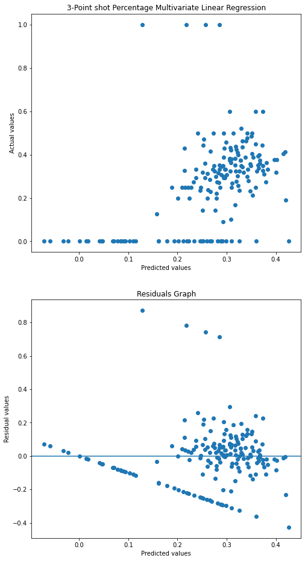

```python
#Multivariate Linear Regression Model for 3P%

#training data
X = nba_with_2K_data[['potential','hustle','intangibles','shot_3pt', 'spot_up_shot_3pt_t', 'shot_3pt_t', 'spot_up_shot_3pt_t', 'off_screen_shot_3pt_t', 'drive_pull_up_3pt_t', 'stepback_jumper_3pt_t','transition_pull_up_3pt_t', 'drive_pull_up_3pt_t']]
Y = nba_with_2K_data['3PointPercent']

#create multivariate linear regression model
lin_reg = LinearRegression().fit(X, Y)
#calculates the 10-cross fold variation of the model
scores = cross_val_score(lin_reg, X, Y, cv=10)
#outputs accuracy of the model according to 10 cross fold variation score
print("Model Accuracy: ", scores.mean())
#print("Actual v. Predicted Results Paired T-Test:", stats.ttest_rel(Y,lin_reg.predict(X)))
#outputs the coefficient of determination of the model
print("Coefficient of Determination:", lin_reg.score(X,Y))
print("Correlation Coefficient:", math.sqrt(lin_reg.score(X,Y)))

#list of predicted values
x_pred = lin_reg.predict(X)
#slope of the linear regresiion model
slope = lin_reg.coef_[0]
#y-intercept of the model
intercept = lin_reg.intercept_
#point-slope form, used to graph line of best fit
y_line = intercept + x_pred*slope

predicted_vs_actual = {'Actual':Y,'Predicted':x_pred, 'Residual':Y-x_pred}
fig, ax = plt.subplots(2, figsize=(8,16))
ax[0].set_title('3-Point shot Percentage Multivariate Linear Regression')
ax[0].set_xlabel('Predicted values')
ax[0].set_ylabel('Actual values')
ax[0].scatter(x_pred, Y)
ax[1].set_title('Residuals Graph')
ax[1].set_xlabel('Predicted values')
ax[1].set_ylabel('Residual values')
ax[1].scatter(x_pred, Y-x_pred)
ax[1].axhline(0)


df = pd.DataFrame(predicted_vs_actual)
df.head(5)
```

```
Model Accuracy:  -0.27099690586155656
Coefficient of Determination: 0.33659741872578863
Correlation Coefficient: 0.5801701635949479
```

|  | Actual | Predicted | Residual |
| --- | --- | --- | --- |
| 0 | 0.500 | 0.510949 | -0.010949 |
| 1 | 0.333 | 0.342697 | -0.009697 |
| 2 | 0.500 | 0.462911 | 0.037089 |
| 3 | 0.424 | 0.605956 | -0.181956 |
| 4 | 0.397 | 0.452342 | -0.055342 |

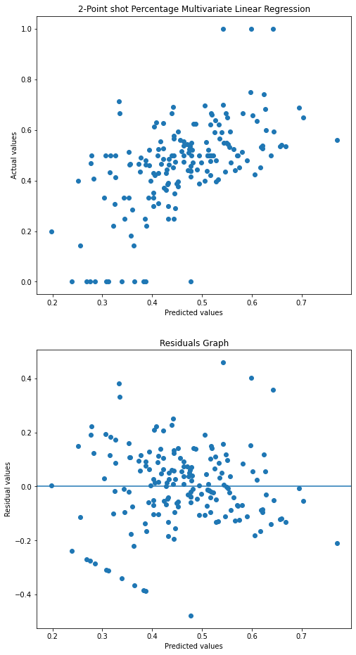

```python
#Multivariate Linear Regression Model for 2P%

#training data
X = nba_with_2K_data[['potential','hustle','intangibles','shot_close', 'shot_mid', 'driving_layup', 'standing_dunk', 'driving_dunk', 'standing_dunk_t', 'driving_dunk_t', 'flashy_dunk_t', 'alley_oop_t', 'putback_dunk_t', 'post_hook', 'post_fade',  'driving_layup_t', 'spin_layup_t', 'hop_step_layup_t', 'euro_step_layup_t', 'floater_t', 'step_through_shot_t', 'shot_under_basket_t', 'shot_close_t', 'shot_close_left_t', 'shot_close_middle_t', 'shot_close_right_t', 'shot_mid_t', 'spot_up_shot_mid_t', 'off_screen_shot_mid_t', 'contested_jumper_mid_t', 'stepback_jumper_mid_t', 'spin_jumper_t', 'drive_pull_up_mid_t', 'shoot_from_post_t', 'post_hook_left_t', 'post_hook_right_t', 'post_fade_left_t', 'post_fade_right_t', 'post_up_and_under_t', 'post_hop_shot_t', 'post_step_back_shot_t' ,'post_shimmy_shot_t']]
Y = nba_with_2K_data['2PointPercent']

#create multivariate linear regression model
lin_reg = LinearRegression().fit(X, Y)
#calculates the 10-cross fold variation of the model
scores = cross_val_score(lin_reg, X, Y, cv=10)
#outputs score obtain from 10 cross fold variation that measures the accuracy of the model
print("Model Accuracy: ", scores.mean())
#print("Actual v. Predicted Results Paired T-Test:", stats.ttest_rel(Y,lin_reg.predict(X)))
#outputs the coefficient of determination of the model
print("Coefficient of Determination:", lin_reg.score(X,Y))
print("Correlation Coefficient:", math.sqrt(lin_reg.score(X,Y)))

#list of values predicted by model when independent variables = X
x_pred = lin_reg.predict(X)
#slope of model
slope = lin_reg.coef_[0]
#y-intercept of model
intercept = lin_reg.intercept_
#point slope form
y_line = intercept + x_pred*slope

predicted_vs_actual = {'Actual':Y,'Predicted':x_pred, 'Residual':Y-x_pred}
fig, ax = plt.subplots(2, figsize=(8,16))
ax[0].set_title('2-Point shot Percentage Multivariate Linear Regression')
ax[0].set_xlabel('Predicted values')
ax[0].set_ylabel('Actual values')
ax[0].scatter(x_pred, Y)
ax[1].set_title('Residuals Graph')
ax[1].set_xlabel('Predicted values')
ax[1].set_ylabel('Residual values')
ax[1].scatter(x_pred, Y-x_pred)
ax[1].axhline(0)

df = pd.DataFrame(predicted_vs_actual)
df.head(5)
```

```
PPG Model Accuracy:  0.1952431519704791
True Shooting Percent Model Accuracy:  -1.406665563801956
Coefficient of Determination: 0.7950423704855999
Correlation Coefficient: 0.8916514848782566
```

|  | Actual | Predicted | Residual |
| --- | --- | --- | --- |
| 0 | 15.2 | 13.898307 | 1.301693 |
| 1 | 1.7 | 4.108167 | -2.408167 |
| 2 | 0.7 | 0.432462 | 0.267538 |
| 3 | 13.9 | 14.417363 | -0.517363 |
| 4 | 7.4 | 5.793657 | 1.606343 |

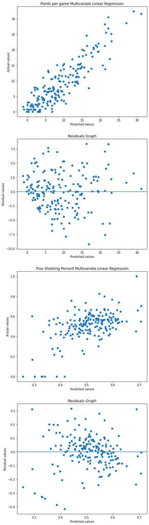

```python
#Multivariate Linear Regression Model for PPG

#training data
#xx = nba_with_2K_data[['name','shot_close', 'shot_mid', 'driving_layup', 'standing_dunk', 'driving_dunk', 'standing_dunk_t', 'driving_dunk_t', 'flashy_dunk_t', 'alley_oop_t', 'putback_dunk_t', 'post_hook', 'post_fade',  'driving_layup_t', 'spin_layup_t', 'hop_step_layup_t', 'euro_step_layup_t', 'floater_t', 'step_through_shot_t', 'shot_under_basket_t', 'shot_close_t', 'shot_close_left_t', 'shot_close_middle_t', 'shot_close_right_t', 'shot_mid_t', 'spot_up_shot_mid_t', 'off_screen_shot_mid_t', 'contested_jumper_mid_t', 'stepback_jumper_mid_t', 'spin_jumper_t', 'drive_pull_up_mid_t', 'shoot_from_post_t', 'post_hook_left_t', 'post_hook_right_t', 'post_fade_left_t', 'post_fade_right_t', 'post_up_and_under_t', 'post_hop_shot_t', 'post_step_back_shot_t' ,'post_shimmy_shot_t', 'shot_3pt', 'spot_up_shot_3pt_t', 'shot_3pt_t', 'spot_up_shot_3pt_t', 'off_screen_shot_3pt_t', 'drive_pull_up_3pt_t', 'stepback_jumper_3pt_t', 'transition_pull_up_3pt_t',  'drive_pull_up_3pt_t', 'use_glass_t', 'free_throw']]
X = nba_with_2K_data[['potential','hustle','intangibles','shot_close', 'shot_mid', 'driving_layup', 'standing_dunk', 'driving_dunk', 'standing_dunk_t', 'driving_dunk_t', 'flashy_dunk_t', 'alley_oop_t', 'putback_dunk_t', 'post_hook', 'post_fade',  'driving_layup_t', 'spin_layup_t', 'hop_step_layup_t', 'euro_step_layup_t', 'floater_t', 'step_through_shot_t', 'shot_under_basket_t', 'shot_close_t', 'shot_close_left_t', 'shot_close_middle_t', 'shot_close_right_t', 'shot_mid_t', 'spot_up_shot_mid_t', 'off_screen_shot_mid_t', 'contested_jumper_mid_t', 'stepback_jumper_mid_t', 'spin_jumper_t', 'drive_pull_up_mid_t', 'shoot_from_post_t', 'post_hook_left_t', 'post_hook_right_t', 'post_fade_left_t', 'post_fade_right_t', 'post_up_and_under_t', 'post_hop_shot_t', 'post_step_back_shot_t' ,'post_shimmy_shot_t', 'shot_3pt', 'spot_up_shot_3pt_t', 'shot_3pt_t', 'spot_up_shot_3pt_t', 'off_screen_shot_3pt_t', 'drive_pull_up_3pt_t', 'stepback_jumper_3pt_t', 'transition_pull_up_3pt_t',  'drive_pull_up_3pt_t', 'use_glass_t', 'free_throw']]
Y = nba_with_2K_data['PPG']
Z = nba_with_2K_data['True Shooting Percent'].fillna(0)


#create multivariate linear regression model
lin_reg = LinearRegression().fit(X, Y)
lin_reg2 = LinearRegression().fit(X, Z)
scores = cross_val_score(lin_reg, X, Y, cv=10)
scores2 = cross_val_score(lin_reg, X, Z, cv=10)

print("PPG Model Accuracy: ", scores.mean())
print("True Shooting Percent Model Accuracy: ", scores2.mean())
#print("PPG Actual v. Predicted Results Paired T-Test:", stats.ttest_rel(Y,lin_reg.predict(X)))
#print("True Shooting Percent Actual v. Predicted Results Paired T-Test:", stats.ttest_rel(Z,lin_reg.predict(X2)))
print("Coefficient of Determination:", lin_reg.score(X,Y))
print("Correlation Coefficient:", math.sqrt(lin_reg.score(X,Y)))


x_pred = lin_reg.predict(X)
x_pred2 = lin_reg2.predict(X)

slope = lin_reg.coef_[0]
slope2 = lin_reg2.coef_[0]

intercept = lin_reg.intercept_
cept2 = lin_reg2.intercept_
y_line = intercept + x_pred*slope
y_line2 = cept2 + slope2*x_pred2

predicted_vs_actual = {'Actual':Y,'Predicted':x_pred, 'Residual':Y-x_pred}
fig, ax = plt.subplots(4, figsize=(8,32))
ax[0].set_title('Points per game Multivariate Linear Regression')
ax[0].set_xlabel('Predicted values')
ax[0].set_ylabel('Actual values')
ax[0].scatter(x_pred, Y)
ax[1].set_title('Residuals Graph')
ax[1].set_xlabel('Predicted values')
ax[1].set_ylabel('Residual values')
ax[1].scatter(x_pred, Y-x_pred)
ax[1].axhline(0)
ax[2].set_title('True Shooting Percent Multivariate Linear Regression')
ax[2].set_xlabel('Predicted values')
ax[2].set_ylabel('Actual values')
ax[2].scatter(x_pred2, Z)
ax[3].set_title('Residuals Graph')
ax[3].set_xlabel('Predicted values')
ax[3].set_ylabel('Residual values')
ax[3].scatter(x_pred2, Z-x_pred2)
ax[3].axhline(0)

#PPG analysis data
df = pd.DataFrame(predicted_vs_actual)
df.head(5)
```

```
Model Accuracy:  0.4224139145314153
Coefficient of Determination: 0.5795886592480722
Correlation Coefficient: 0.7613072042533633
```

|  | Actual | Predicted | Residual |
| --- | --- | --- | --- |
| 0 | 7.2 | 6.503923 | 0.696077 |
| 1 | 0.0 | 2.024423 | -2.024423 |
| 2 | 0.0 | 1.719123 | -1.719123 |
| 3 | 9.0 | 6.115408 | 2.884592 |
| 4 | 6.3 | 4.200745 | 2.099255 |
| ... | ... | ... | ... |
| 172 | 2.5 | 2.311772 | 0.188228 |
| 173 | 4.8 | 3.568293 | 1.231707 |
| 174 | 1.5 | 3.765388 | -2.265388 |
| 175 | 3.6 | 3.683249 | -0.083249 |
| 176 | 0.0 | 2.127072 | -2.127072 |

177 rows × 3 columns

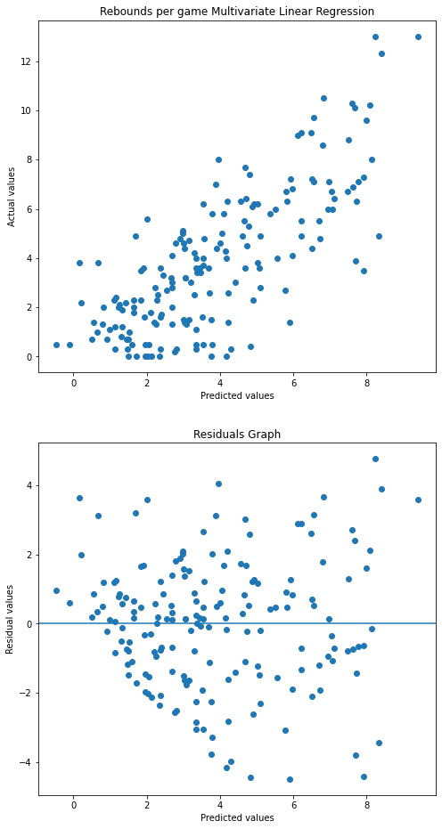

```python
#Multivariate Linear Regression Model for RPG

#training data
X = nba_with_2K_data[['potential','hustle','intangibles','height','vertical', 'strength', 'stamina', 'hustle', 'overall_durability', 'post_moves', 'offensive_rebound', 'defensive_rebound', 'putback_dunk_t', 'crash_t']]
Y = nba_with_2K_data['RPG']

#create multivariate linear regression model
lin_reg = LinearRegression().fit(X, Y)
scores = cross_val_score(lin_reg, X, Y, cv=10)
print("Model Accuracy: ", scores.mean())
#print("Actual v. Predicted Results Paired T-Test:", stats.ttest_rel(Y,lin_reg.predict(X)))
print("Coefficient of Determination:", lin_reg.score(X,Y))
print("Correlation Coefficient:", math.sqrt(lin_reg.score(X,Y)))

x_pred = lin_reg.predict(X)
slope = lin_reg.coef_[0]
intercept = lin_reg.intercept_
y_line = intercept + x_pred*slope

predicted_vs_actual = {'Actual':Y,'Predicted':x_pred, 'Residual':Y-x_pred}
fig, ax = plt.subplots(2, figsize=(8,16))
ax[0].set_title('Rebounds per game Multivariate Linear Regression')
ax[0].set_xlabel('Predicted values')
ax[0].set_ylabel('Actual values')
ax[0].scatter(x_pred, Y)
ax[1].set_title('Residuals Graph')
ax[1].set_xlabel('Predicted values')
ax[1].set_ylabel('Residual values')
ax[1].scatter(x_pred, Y-x_pred)
ax[1].axhline(0)

df = pd.DataFrame(predicted_vs_actual)
df.head(5)
df = pd.DataFrame(predicted_vs_actual)
df
```

```
Model Accuracy:  0.41444316651216984
Coefficient of Determination: 0.613142503591118
Correlation Coefficient: 0.7830341650216279
```

|  | Actual | Predicted | Residual |
| --- | --- | --- | --- |
| 0 | 3.6 | 2.460815 | 1.139185 |
| 1 | 0.0 | 2.805365 | -2.805365 |
| 2 | 0.0 | -0.369270 | 0.369270 |
| 3 | 4.4 | 2.879377 | 1.520623 |
| 4 | 1.3 | -0.115881 | 1.415881 |

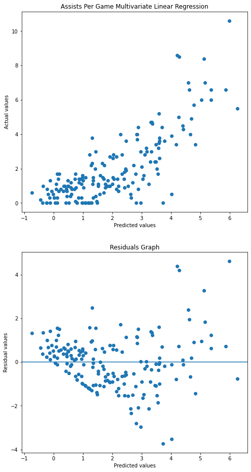

```python
#Multivariate Linear Regression Model for APG

#training data
X = nba_with_2K_data[['potential','hustle','intangibles','passing_accuracy', 'passing_vision', 'passing_iq', 'pass_perception', 'dish_to_open_man_t', 'flashy_pass_t', 'alley_oop_pass_t']]
Y = nba_with_2K_data['AssistsPG']

#create multivariate linear regression model
lin_reg = LinearRegression().fit(X, Y)
scores = cross_val_score(lin_reg, X, Y, cv=10)
print("Model Accuracy: ", scores.mean())
#print("Actual v. Predicted Results Paired T-Test:", stats.ttest_rel(Y,lin_reg.predict(X)))
print("Coefficient of Determination:", lin_reg.score(X,Y))
print("Correlation Coefficient:", math.sqrt(lin_reg.score(X,Y)))


x_pred = lin_reg.predict(X)
slope = lin_reg.coef_[0]
intercept = lin_reg.intercept_
y_line = intercept + x_pred*slope

predicted_vs_actual = {'Actual':Y,'Predicted':x_pred, 'Residual':Y-x_pred}
fig, ax = plt.subplots(2, figsize=(8,16))
ax[0].set_title('Assists Per Game Multivariate Linear Regression')
ax[0].set_xlabel('Predicted values')
ax[0].set_ylabel('Actual values')
ax[0].scatter(x_pred, Y)
ax[1].set_title('Residuals Graph')
ax[1].set_xlabel('Predicted values')
ax[1].set_ylabel('Residual values')
ax[1].scatter(x_pred, Y-x_pred)
ax[1].axhline(0)

df = pd.DataFrame(predicted_vs_actual)
df.head(5)
```

```
Model Accuracy:  0.24818804622157006
Coefficient of Determination: 0.41203661374759776
Correlation Coefficient: 0.6419007818561976
```

|  | Actual | Predicted | Residual |
| --- | --- | --- | --- |
| 0 | 1.20 | 0.761818 | 0.438182 |
| 1 | 0.00 | 0.529186 | -0.529186 |
| 2 | 0.00 | 0.067618 | -0.067618 |
| 3 | 0.44 | 0.659348 | -0.219348 |
| 4 | 0.56 | 0.347342 | 0.212658 |

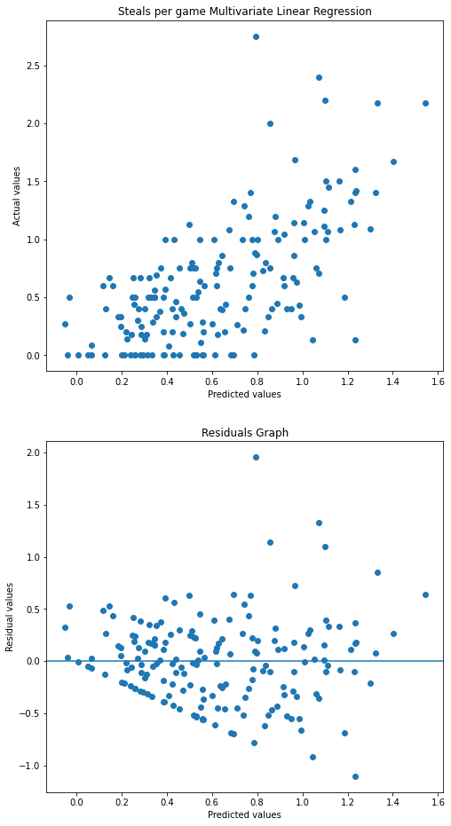

```python
#Multivariate Linear Regression Model for Steals

#training data
X = nba_with_2K_data[['potential','intangibles','hands', 'speed', 'acceleration', 'hustle', 'ball_handle', 'steal',  'on_ball_steal_t', 'pass_interception_t']]
Y = nba_with_2K_data['StealsPG']

#create multivariate linear regression model
lin_reg = LinearRegression().fit(X, Y)
scores = cross_val_score(lin_reg, X, Y, cv=10)
print("Model Accuracy: ", scores.mean())
#print("Actual v. Predicted Results Paired T-Test:", stats.ttest_rel(Y,lin_reg.predict(X)))
print("Coefficient of Determination:", lin_reg.score(X,Y))
print("Correlation Coefficient:", math.sqrt(lin_reg.score(X,Y)))


x_pred = lin_reg.predict(X)
slope = lin_reg.coef_[0]
intercept = lin_reg.intercept_
y_line = intercept + x_pred*slope

predicted_vs_actual = {'Actual':Y,'Predicted':x_pred, 'Residual':Y-x_pred}
fig, ax = plt.subplots(2, figsize=(8,16))
ax[0].set_title('Steals per game Multivariate Linear Regression')
ax[0].set_xlabel('Predicted values')
ax[0].set_ylabel('Actual values')
ax[0].scatter(x_pred, Y)
ax[1].set_title('Residuals Graph')
ax[1].set_xlabel('Predicted values')
ax[1].set_ylabel('Residual values')
ax[1].scatter(x_pred, Y-x_pred)
ax[1].axhline(0)

df = pd.DataFrame(predicted_vs_actual)
df.head(5)
```

```
Model Accuracy:  0.18637998553902016
Coefficient of Determination: 0.41735603675021793
Correlation Coefficient: 0.646030987453557
```

|  | Actual | Predicted | Residual |
| --- | --- | --- | --- |
| 0 | 0.20 | 0.515079 | -0.315079 |
| 1 | 0.00 | 0.346637 | -0.346637 |
| 2 | 0.33 | 0.402809 | -0.072809 |
| 3 | 0.78 | 0.972958 | -0.192958 |
| 4 | 0.63 | 0.288258 | 0.341742 |

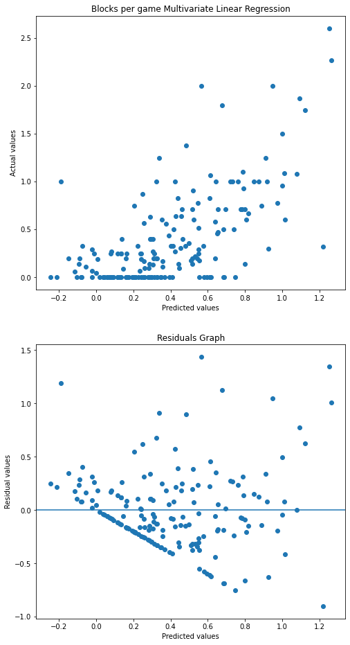

```python
#Multivariate Linear Regression Model for BPG

#training data
X = nba_with_2K_data[['potential','hustle','intangibles','block', 'block_shot_t', 'shot_contest', 'vertical', 'strength', 'stamina', 'contest_shot_t']]
Y = nba_with_2K_data['BlocksPG']

#create multivariate linear regression model
lin_reg = LinearRegression().fit(X, Y)
scores = cross_val_score(lin_reg, X, Y, cv=10)
print("Model Accuracy: ", scores.mean())
#print("Actual v. Predicted Results Paired T-Test:", stats.ttest_rel(Y,lin_reg.predict(X)))
print("Coefficient of Determination:", lin_reg.score(X,Y))
print("Correlation Coefficient:", math.sqrt(lin_reg.score(X,Y)))

x_pred = lin_reg.predict(X)
slope = lin_reg.coef_[0]
intercept = lin_reg.intercept_
y_line = intercept + x_pred*slope

predicted_vs_actual = {'Actual':Y,'Predicted':x_pred, 'Residual':Y-x_pred}
fig, ax = plt.subplots(2, figsize=(8,16))
ax[0].set_title('Blocks per game Multivariate Linear Regression')
ax[0].set_xlabel('Predicted values')
ax[0].set_ylabel('Actual values')
ax[0].scatter(x_pred, Y)
ax[1].set_title('Residuals Graph')
ax[1].set_xlabel('Predicted values')
ax[1].set_ylabel('Residual values')
ax[1].scatter(x_pred, Y-x_pred)
ax[1].axhline(0)

df = pd.DataFrame(predicted_vs_actual)
df.head(5)
```

```
Model Accuracy:  -0.02311242017471113
Coefficient of Determination: 0.09337262246394873
Correlation Coefficient: 0.3055693414986993
```

|  | Actual | Predicted | Residual |
| --- | --- | --- | --- |
| 0 | 0.526 | 0.740074 | -0.214074 |
| 1 | 0.000 | 0.626512 | -0.626512 |
| 2 | 0.000 | 0.550336 | -0.550336 |
| 3 | 0.833 | 0.727846 | 0.105154 |
| 4 | 0.750 | 0.602295 | 0.147705 |

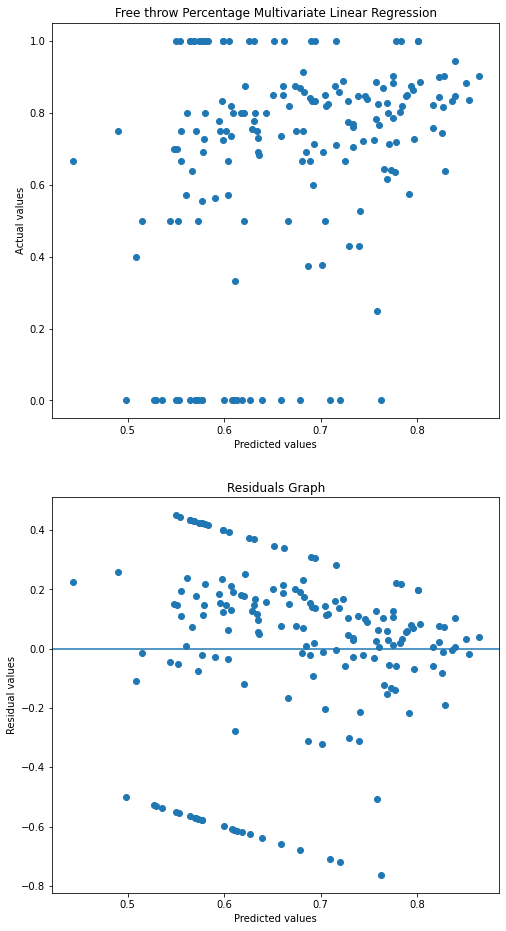

```python
#Multivariate Linear Regression Model for Free Throw Percentage

#training data
X = nba_with_2K_data[['potential','hustle','intangibles','free_throw']]
Y = nba_with_2K_data['Free Throw Percentage']

#create multivariate linear regression model
lin_reg = LinearRegression().fit(X, Y)
scores = cross_val_score(lin_reg, X, Y, cv=10)
print("Model Accuracy: ", scores.mean())
#print("Actual v. Predicted Results Paired T-Test:", stats.ttest_rel(Y,lin_reg.predict(X)))
print("Coefficient of Determination:", lin_reg.score(X,Y))
print("Correlation Coefficient:", math.sqrt(lin_reg.score(X,Y)))


x_pred = lin_reg.predict(X)
slope = lin_reg.coef_[0]
intercept = lin_reg.intercept_
y_line = intercept + x_pred*slope

predicted_vs_actual = {'Actual':Y,'Predicted':x_pred, 'Residual':Y-x_pred}
fig, ax = plt.subplots(2, figsize=(8,16))
ax[0].set_title('Free throw Percentage Multivariate Linear Regression')
ax[0].set_xlabel('Predicted values')
ax[0].set_ylabel('Actual values')
ax[0].scatter(x_pred, Y)
ax[1].set_title('Residuals Graph')
ax[1].set_xlabel('Predicted values')
ax[1].set_ylabel('Residual values')
ax[1].scatter(x_pred, Y-x_pred)
ax[1].axhline(0)

df = pd.DataFrame(predicted_vs_actual)
df.head(5)
```

## Analysis:

Based on the Actual values vs Predicted values scatterplots and the Residual values scatterplots, we can see that some real-life NBA stats do have strong linear relationships with their representative statistics in NBA2K. The point distribution and shape for the Actual values vs Predicted values scatterplots and the Residual values scatterplots for Points Per Game (PPG), Assists Per Game (AssistsPG), and Rebounds Per Game (RPG) indicate that there is a strong linear relationship between these real-life NBA player statistics and specific player statistics in NBA2K.

The correlation coefficients for Points Per Game (PPG), Assists Per Game (AssistsPG), and Rebounds Per Game (RPG) are 0.8916514848782566, 0.7830341650216279, and 0.7613072042533633 respectively. A correlation coefficient greater than or equal to 0.7 typical indicates a strong linear relationship between the independent and dependent variables. Thus, we can conclude that Points Per Game (PPG), Assists Per Game (AssistsPG), and Rebounds Per Game (RPG) (dependent variables) have a strong linear relationship with their representative NBA2K statistics (independent variables).

Based on the shape of their Actual values vs Predicted values scatterplots and the Residual values scatterplot for 2P%, Steals, and BPG appears to have moderate linear relationships with NBA2K statistics.

The correlation coefficients for the 2P%, Steals, and BPG models are 0.5801701635949479, 0.6419007818561976, and 0.646030987453557 respectively. The values of the aforementioned correlation coefficient indicate that 2P%, Steals, and BPG (dependent variables) do have moderate linear relationships with NBA2K statistics (independent variables).

However, the remainder of the real-life NBA2K stats appears to have a weak or no linear relationship with their representative NBA2K statistics. The point distribution and shape for the Actual values vs Predicted values scatterplots and the Residual values scatterplots for 3P% and Free Throw % indicates that there is a weak linear relationship or no relationship between these real-life statistics and their representative statistics in NBA2K.

The correlation coefficients for the 3P% and Free Throw % models are 0.4937702103631969 and 0.3055693414986993 respectively. The values of these correlation coefficients indicate that 3P% and Free Throw% (dependent variables) have a weak linear relationship with NBA2K statistics (independent variables).

## Conclusion:

The data analysis yields the conclusion that there is a relationship between real life NBA statistics and in-game statistics in NBA2K. 6 of the 8 key real-life NBA statistics that were analyzed -Points Per Game (PPG), Assists Per Game (AssistsPG), Rebounds Per Game (RPG), 2P%, Steals, and BPG (Blocks Per Game- had strong or moderate correlations with the in-game player statistics in NBA2K. However, two real-life NBA statistics - 3P% and Free Throw % - had weak correlations with the in-game statistics in NBA2K.

Overall, we can conclude that the in-game player statistics in NBA 2K do have some basis in real-life NBA player statistics. However, further analysis will need to be done before it can be determined how the developers translate real-life NBA player statistics into NBA2K in-game player statistics. It remains unclear how certain, more abstract in-game statistics such as potential, intangibles, and hustle are derived from real-life NBA statistics. It also remains unclear how much in-game statistics are directly altered by developers for balance/gameplay purposes, which may explain why some real-life statistics have only a moderate or weak correlation to in-game statistics.

The field of data science as a whole is gaining traction in the mainstream community and is expanding faster than ever before. With this new global focus on AI development and Machine Learning, the methods of determining a professional athlete's abilities for a video game with extreme accuracy could just be the algorithms upon which more complex neural networks are born.

## External resources:

The quest to understand the meaning behind player ratings in-game is not a new one. A user on Reddit discovered the specific details of what goes into a player's overall rating and gave a detailed analysis of their findings in a post linked here - https://www.reddit.com/r/NBA2k/comments/5zl48j/the_secrets_of_overall/.

Additionally, this Complex article takes a look at NBA 2K statistics in an effort to clear some of the mystery surrounding some of the more vague rating categories like "hustle" and "potential." https://www.complex.com/sports/2017/10/how-nba-2k-determines-player-rankings

A piece of documentation from the python sci-kit-learn module. It informed us of the definition of k cross-fold validation, and how to obtain the accuracy of a model from the score returned by the cross_val_score function.

https://scikit-learn.org/stable/modules/generated/sklearn.model_selection.cross_val_score.html

A page from the popular statistics website, Statistics How To, informs the reader of the definition of a coefficient of determination and how to calculate the coefficient of determination of a linear model.

https://www.statisticshowto.com/probability-and-statistics/coefficient-of-determination-r-squared/

A page from the popular statistics website, Statistics How To, informs the reader of the definition of a correlation coefficient and how to calculate the correlation coefficient of a linear model.

https://www.statisticshowto.com/probability-and-statistics/correlation-coefficient-formula/